# Analysis of Pre-HFD CLAMS Data for High Fat Diet Particulate Treatment Study

Dave Bridges, Alyse Ragauskas, Erin Stephenson, JeAnna Redd, Jyothi Parvathareddy, Sridhar Jaligama, Stephania Cormier and Joan Han

November 13, 2014

This was the data from the CLAMS study performed on the 9 week old mice. This script was most recently run on Tue Mar 22 14:42:17 2016.

The input files were ../data/CLAMS/2014-09-15 Maternal Particulate.xlsx for the echoMRI data and ../data/CLAMS/2014-09-15/2014-09-15 Maternal Particulate OXYMAX.csv and ../data/CLAMS/2014-09-19/2014-09-19 Maternal Particulate OXYMAX.csv for the CLAMS data.

## Resting Metabolic Rate

The VO2 levels were first merged to average over light and dark cycles, removing the first 40 measurements. To analyse these data we performed an ANCOVA analysis using body weight as the primary covariate.

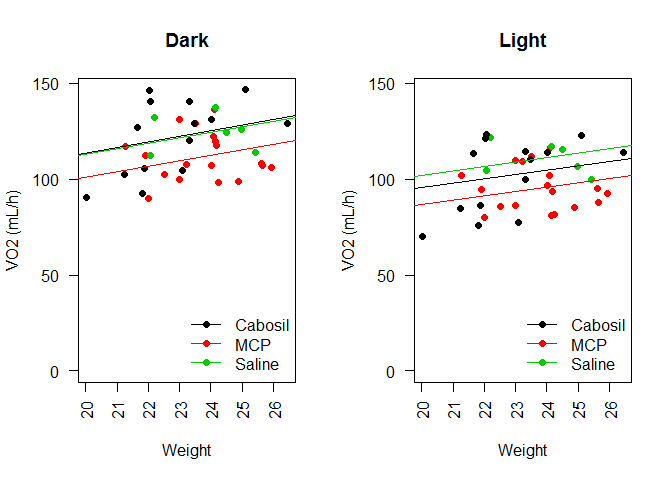

We first checked whether normality was maintained in the residuals from the ANCOVA. The normality assumption was met for both Dark (p=0.3366) and Light (p=0.1831) via Shapiro-Wilk test.

According to this analysis there was no significant effect of the treatment group on the body weight-adjusted VO2 levels under either Dark (p=0.0511) or Light (p=0.0545) conditions. There was also no significant effect of body weight in either Dark (p=0.2273) or Light (p=0.2334) conditions. We detected a -18.1115% reduction in metabolic rate between MCP and Cabosil groups in the light and a -22.7307% reduction in the dark.

Alternatively we used a mixed linear model, with non-interacting covariates for the Light cycle, the Weight and the Particulate treatment. A F-test comparing a model with or without the Particulate treatment yielded a p-value of 0.0452. Post-hoc tests for the effects of particulate treatment are shown in the Table below. According to this MCP treatment reduces VO2 by -6.2656%, p=0.0526.

Post-hoc Dunnett’s tests of mixed linear model correcting for effects of light cycle and total body mass on V02. P-values are not corrected.

|  | Coefficient | p.value |
| --- | --- | --- |
| (Intercept) | 7111 | 0.000 |
| Light.DarkLight | -742 | 0.000 |
| Weight | -81 | 0.256 |
| Particulate.TreatmentMCP | -446 | 0.053 |
| Particulate.TreatmentSaline | 146 | 0.640 |

Post-hoc Dunnett’s sests of mixed linear model correcting for effects of light cycle and lean body mass on V02. P-values are not corrected.

|  | Coefficient | p.value |
| --- | --- | --- |
| (Intercept) | 8024 | 0.000 |
| Light.DarkLight | -742 | 0.000 |
| Lean | -141 | 0.127 |
| Particulate.TreatmentMCP | -403 | 0.080 |
| Particulate.TreatmentSaline | 152 | 0.618 |

## Normalization by Lean Body Mass

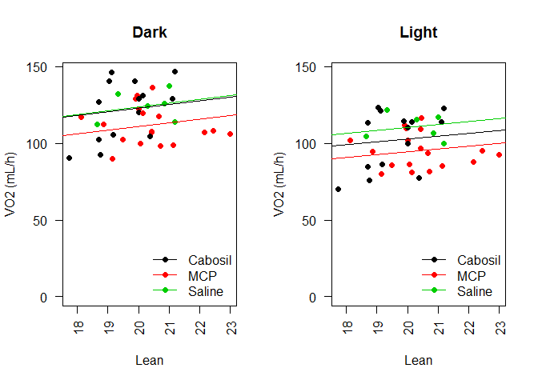

Using the lean mass as the covariate, we checked whether normality was maintained in the residuals from the ANCOVA. The normality assumption was met for both Dark (p=0.3594) and Light (p=0.2121) via Shapiro-Wilk test.

According to this analysis there was no significant effect of the treatment group on the body weight-adjusted VO2 levels under either Dark (p=0.0681) or Light (p=0.0584) conditions. There was also no effect of body weight in either Dark (p=0.6657) or Light (p=0.6296) conditions. Analysed this way, we detected a -13.0493% reduction in metabolic rate between MCP and Cabosil groups in the light and a -16.1924% reduction in the dark.

There was no significant difference between Cabosil and Saline (p=0.9066 from a *t* test between linear models). We therefore repeated this analysis but combined Cabosil and Saline to get more statistical power.

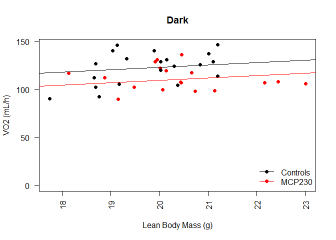

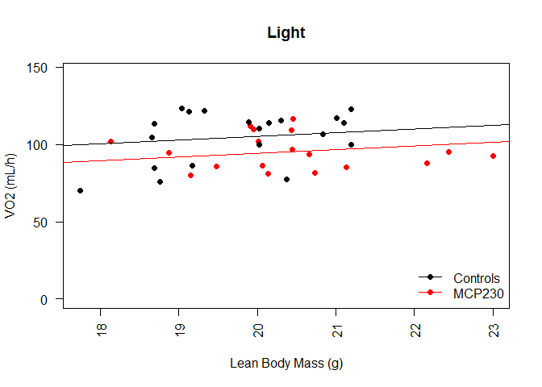

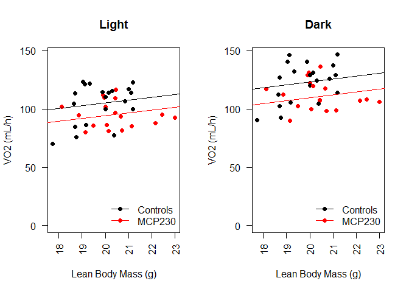

According to this analysis there was a significant effect of the treatment group on the body weight-adjusted VO2 levels under either Dark (p=0.0197) or Light (p=0.0311) conditions. There was no effect of body weight in either Dark (p=0.6611) or Light (p=0.6301) conditions. Analysed this way, we detected a -19.0936% reduction in metabolic rate between MCP and Control groups in the light and a -16.7803% reduction in the dark.

Alternatively we used a mixed linear model, with non-interacting covariates for the Light cycle, the Lean Body Mass and the Particulate treatment. A Chi-squared test comparing a model with or without the Particulate treatment yielded a p-value of 0.0702. Post-hoc tests for the effects of particulate treatment are shown in the table below. According to this MCP treatment reduces VO2 by -5.0212%, p=0.0802.

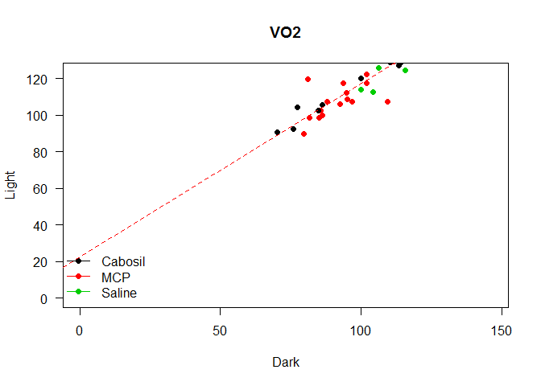

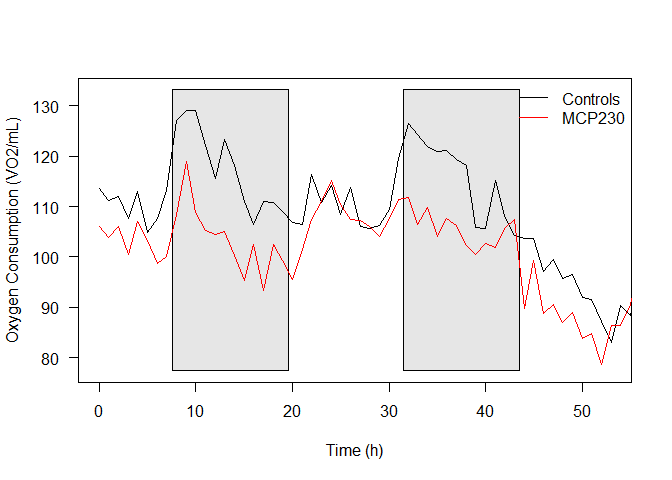

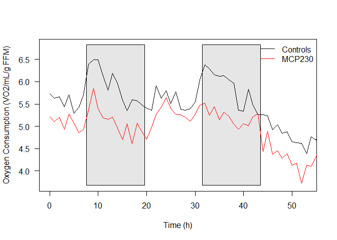

## Calorimetry by Heat Production

Another way to present these data is to evaluate this by heat instead of VO2. The equation for Heat production from the CLAMS is the Lusk Equation:

$$(3.815 + 1.232 * RER)*VO2$$

To analyse these data we performed an ANCOVA analysis using body weight as the primary covariate.

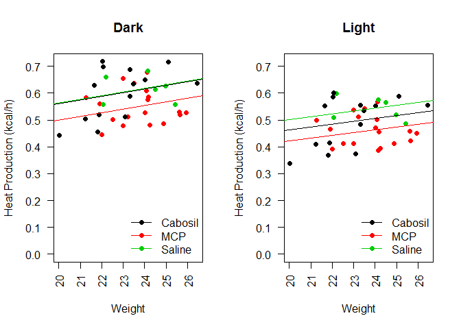

We first checked whether normality was maintained in the residuals from the ANCOVA. The normality assumption was met for both Dark (p=0.2176) and Light (p=0.2533) via Shapiro-Wilk test.

Post-hoc Dunnett’s tests of mixed linear model correcting for effects of light cycle and total body mass on heat production. P-values are not corrected.

|  | Coefficient | p.value |
| --- | --- | --- |
| (Intercept) | 0 | 0.072 |
| Light.DarkLight | -0 | 0.000 |
| Weight | 0 | 0.121 |
| Particulate.TreatmentMCP | -0 | 0.037 |
| Particulate.TreatmentSaline | 0 | 0.528 |

Post-hoc Dunnett’s sests of mixed linear model correcting for effects of light cycle and lean body mass on heat production. P-values are not corrected.

|  | Coefficient | p.value |
| --- | --- | --- |
| (Intercept) | 0 | 0.045 |
| Light.DarkLight | -0 | 0.000 |
| Lean | 0 | 0.367 |
| Particulate.TreatmentMCP | -0 | 0.060 |
| Particulate.TreatmentSaline | 0 | 0.412 |

## Normalization by Lean Body Mass

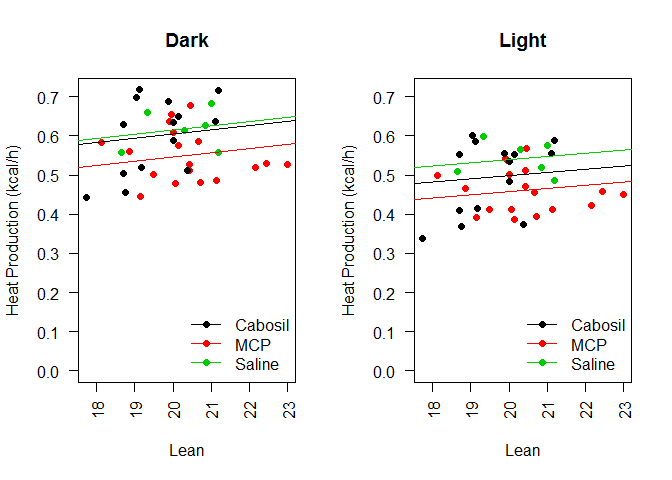

Using the lean mass as the covariate, we checked whether normality was maintained in the residuals from the ANCOVA. The normality assumption was met for both Dark (p=0.2575) and Light (p=0.2385) via Shapiro-Wilk test.

According to this analysis there was no significant effect of the treatment group on the body weight-adjusted heat produciton levels under either Dark (p=0.0696) or Light (p=0.0506) conditions. There was also no effect of body weight in either Dark (p=0.7252) or Light (p=0.6905) conditions. Analysed this way, we detected a -11.9637% reduction in metabolic rate between MCP and Cabosil groups in the light and a -15.1485% reduction in the dark.

There was no significant difference between Cabosil and Saline (p=0.7907 from a *t* test between linear models). We therefore repeated this analysis but combined Cabosil and Saline to get more statistical power.

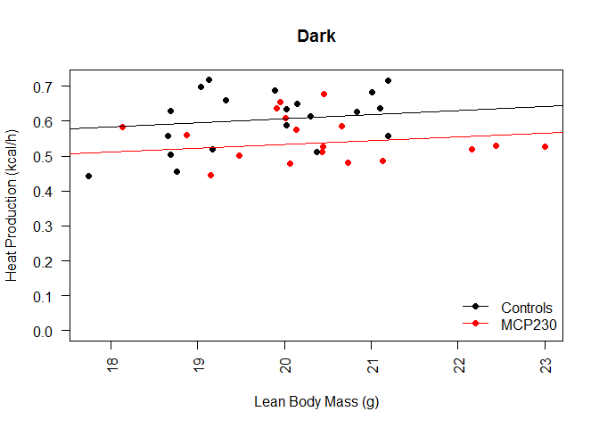

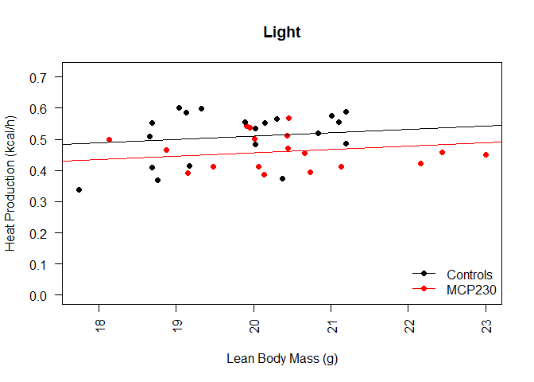

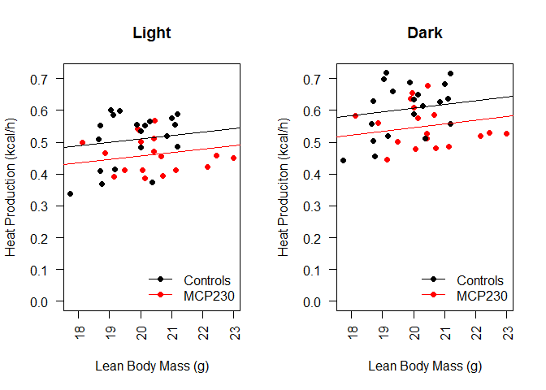

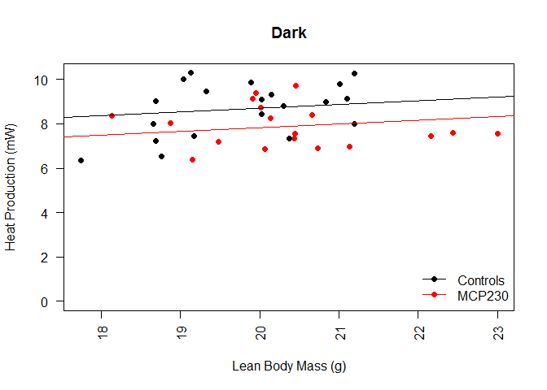

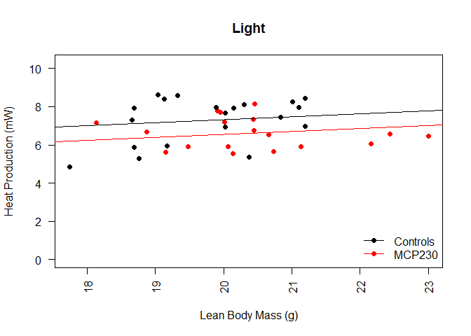

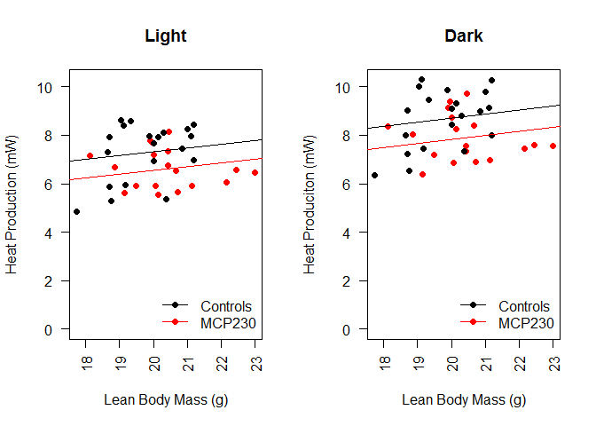

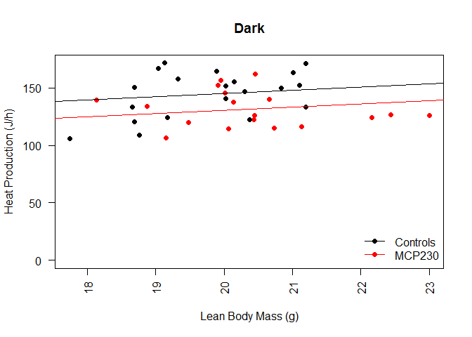

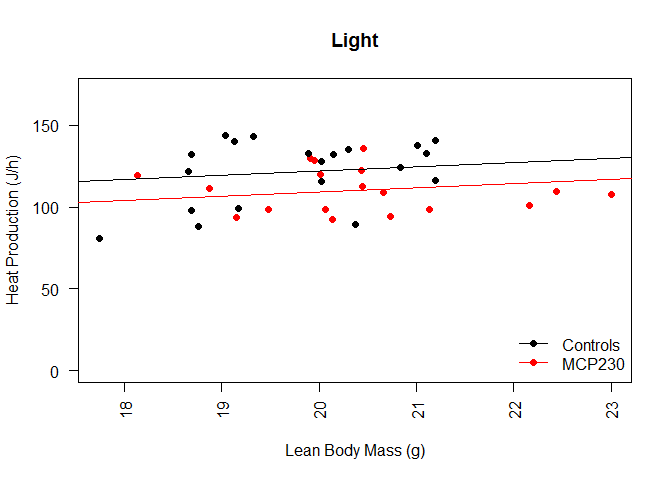

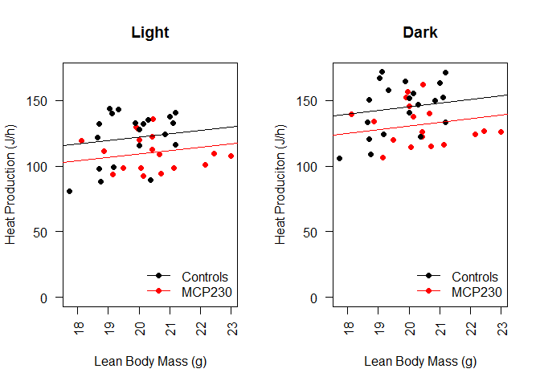

According to this analysis there was a significant effect of the treatment group on the body weight-adjusted heat produciton levels under either Dark (p=0.0209) or Light (p=0.0316) conditions. There was no effect of body weight in either Dark (p=0.7215) or Light (p=0.6922) conditions. Analysed this way, we detected a -18.4166% reduction in metabolic rate between MCP and Control groups in the light and a -16.4381% reduction in the dark.

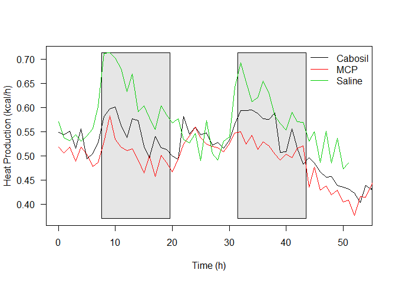

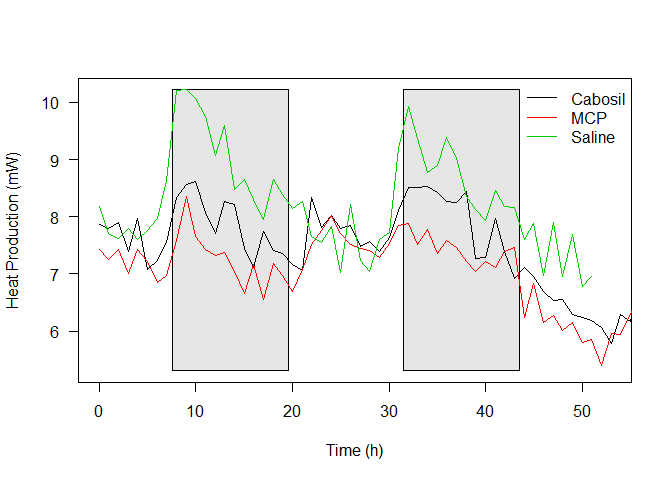

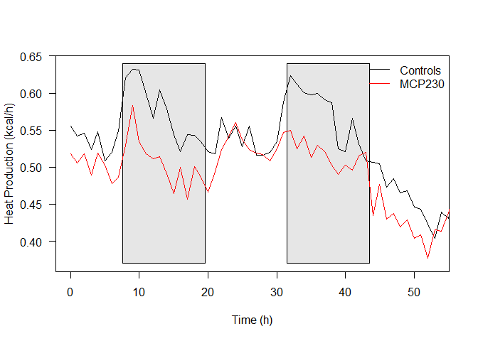

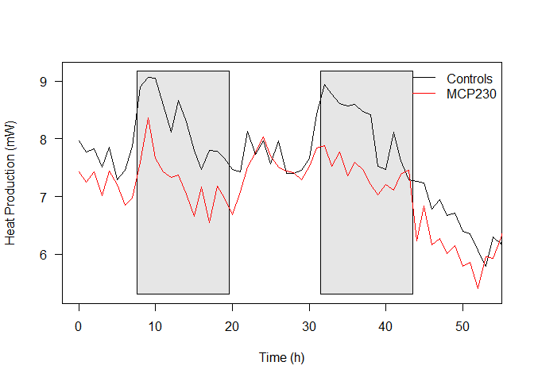

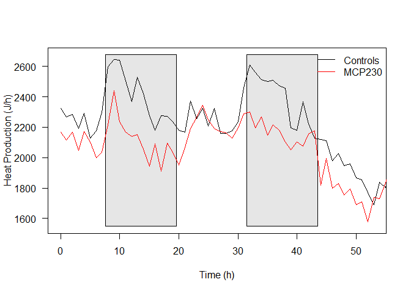

# Body Weights and Composition

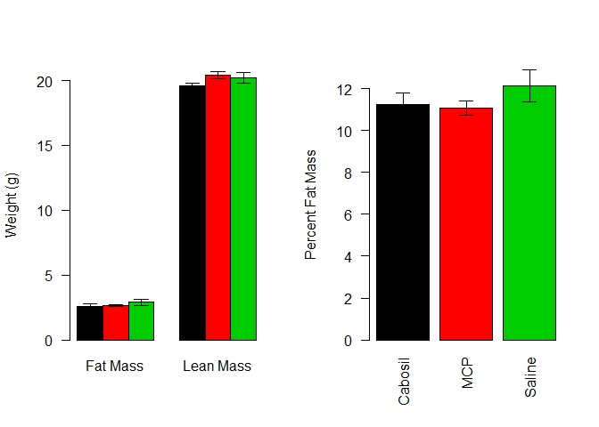

The assumptions of normality were met via a Shapiro-Wilk Test for Total Mass (p=0.7135), and Lean Mass (p=0.9306). The assumptions of equal varaince were met for Total Mass (p=0.7128), and Lean Mass (p=0.9623. Based on this there was no significant differentces in Total Mass (p=0.1642) or Lean Mass (p=0.1196) by ANOVA.

These assumptions or normality were not met for Fat Mass (p=0.0028) or Percent Fat Mass (p=0.0448), so we did Kruskal-Wallis tests instead. According to these tests there was no significant differences in these groups either for Fat Mass (p=0.2596) or Percent Fat Mass (p=0.4293).

# Respiratory Exchange Rate

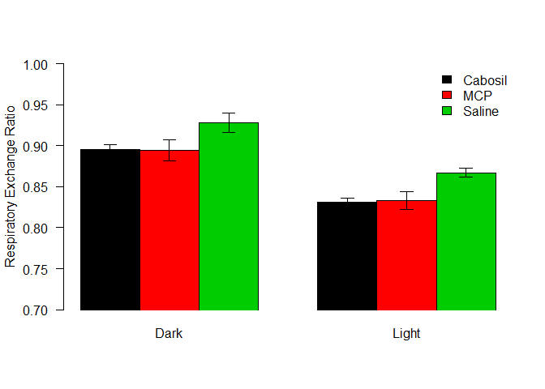

The assumptions of normality was not met for either Light (p=0.0176) or Dark RER (p=0.0141) levels via a Shapiro-Wilk test. We therefore did a Kruskal-Wallis test and found that while Dark (p=0.1024) RER levels not were significantly different, Light RER levels were (p=0.0282). Post-hoc tests for Light RER levels are shown in the Table below:

Pairwise Wilcoxon Rank-Sum Tests, corrected by Benjamini-Hochberg

|  | Cabosil | MCP |
| --- | --- | --- |
| MCP | 0.4876 |  |
| Saline | 0.0011 | 0.2048 |

# Activity Data

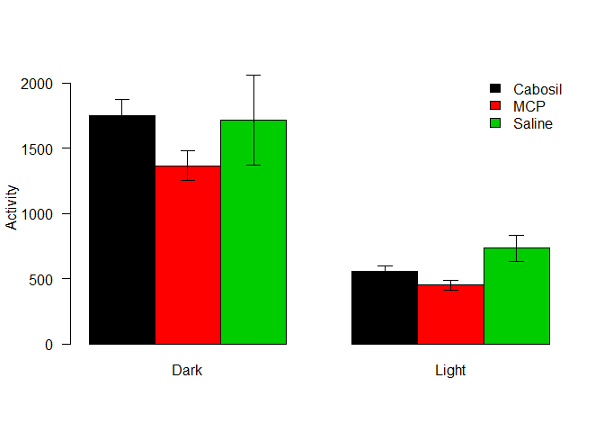

The assumptions of normality was met for both Light (p=0.8414) or Dark activity (p=0.6165) levels via a Shapiro-Wilk test. As for the assumptions of equal variance, both Dark (p=0.2917), and Light activity levels (p=0.656) met this assumption via Levene’s test. We therefore did an ANOVA and found that while Dark (p=0.1236) activity levels not were significantly different, Light activity levels were (p=0.0048). Post-hoc tests for Light activity levels are shown in the table below:

Pairwise Student’s T-Tests, corrected by Benjamini-Hochberg

|  | Cabosil | MCP |
| --- | --- | --- |
| MCP | 0.0911 |  |
| Saline | 0.0661 | 0.0041 |

Since the cabosil and saline treated groups were not significantly different (p=0.1477), we combined these groups.

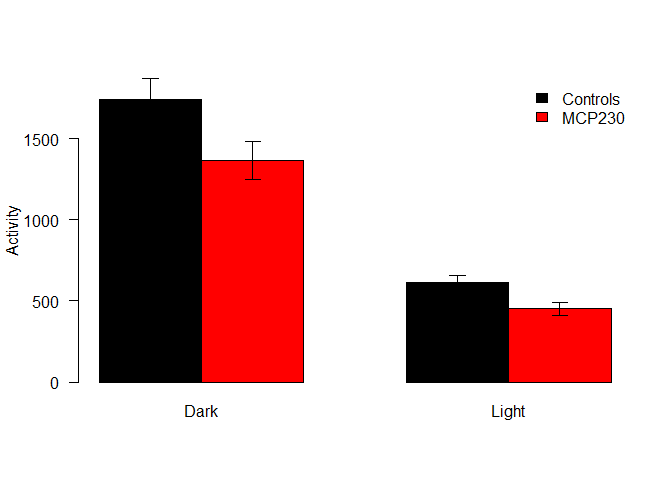

After combining these groups, the assumptions of normality (Dark p > 0.5248; Light 0.6253) and equal variance were still (Dark p=0.8047; Light p=0.4951) met.

Based on these data, there was a -21.4592 % reduction in activity in the dark phase (p=0.0398) and a -26.2358 % reduction in activity in the light phase (p=0.0099).

# Food Intake

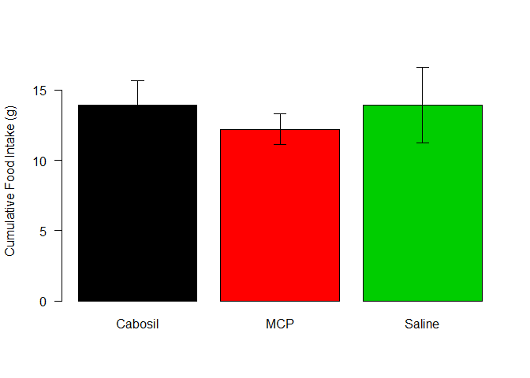

## Detailed Food Intake Analysis

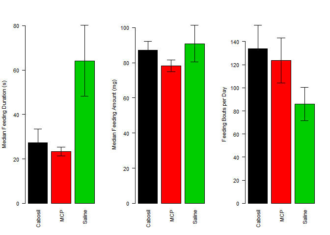

These data can be found in the folder ../data/CLAMS/Feeding bouts/. We calculated an median duration and median feeding amount, after excluding feeding bouts >0.5g and feeding amounts >300s. Greater than 100 feeding bouts had to be detected per animal.

### Feeding Duration

Pairwise Wilcox Rank Sum tests, adjusted by the method of Benjamini and Hochberg

|  | Cabosil | MCP |
| --- | --- | --- |
| MCP | 0.6025 | NA |
| Saline | 0.0212 | 0.0212 |

## Feeding Bouts

Normality cannot be assumed for feeding duration (p=0.0055). An Kruskal-Wallis test shows no significant difference between feeding durations (p=0.4883).

## Separating Feeding Behavior by Day and Night

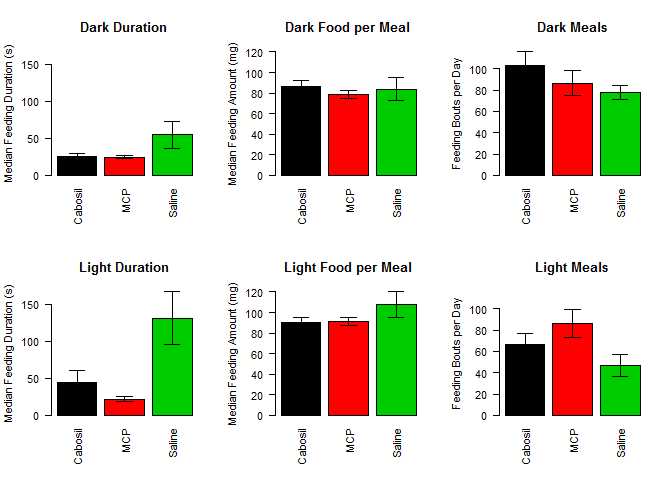

### Individualized Feeding Behavior

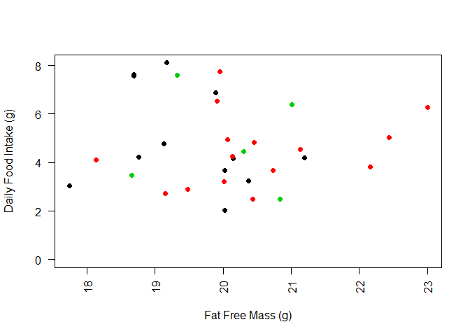

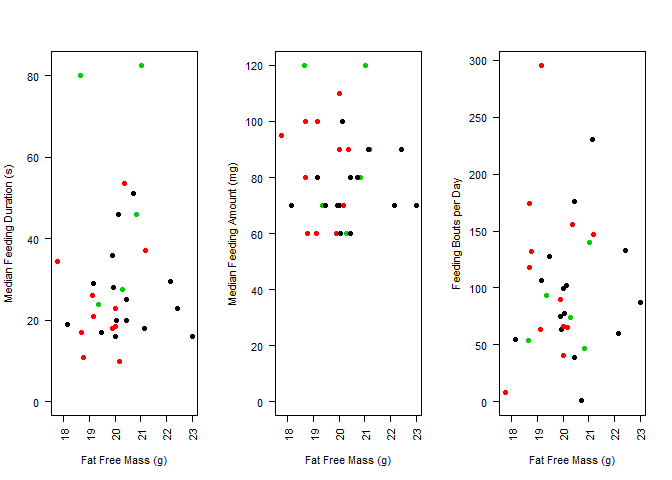